# Laboratorio 3

Oliver Mazariegos, Rafael Leon y Alejandro Vasquez

07/10/2018

# Analisis Exploratorio

## Reviews

Para realizar el siguiente analisis de sentimientos utilizaremos una muestra aleatoria de 30% de los datos. Para poder analizar cada review del dataset utilizaremos `VectorSource` y luego realizaremos el corpus.

```r
texto = paste(reviews$reviews.text, collapse = " ")
review_source = VectorSource(texto)
corpus = Corpus(review_source)
```

## Limpieza de Datos

Para la limpieza de datos realizaremos los siguientes pasos.

- Pasar todo a minusculas.
- Remover los simbolos de puntuacion.
- Remover los numeros.
- Remover los espacios en blanco.
- Remover los StopWords

```r
corpus = tm_map(corpus,content_transformer(tolower))
corpus = tm_map(corpus,content_transformer(removePunctuation))
corpus = tm_map(corpus,content_transformer(removeNumbers))
corpus = tm_map(corpus,stripWhitespace)
corpus = tm_map(corpus,removeWords,tm::stopwords(kind="en"))
```

## Document Term Matrix

La matriz de terminos nos ayudara a obtener una lista de cada palabra por separado.

```r
dtm = DocumentTermMatrix(corpus)
dtm2 = as.matrix(dtm)
```

## WordCloud e Histograma

Con la matriz de terminos realizada, representemos con una nube de palabras las palabras que mas se repiten y veremos con un grafico de barras la frecuencia de estas mismas.

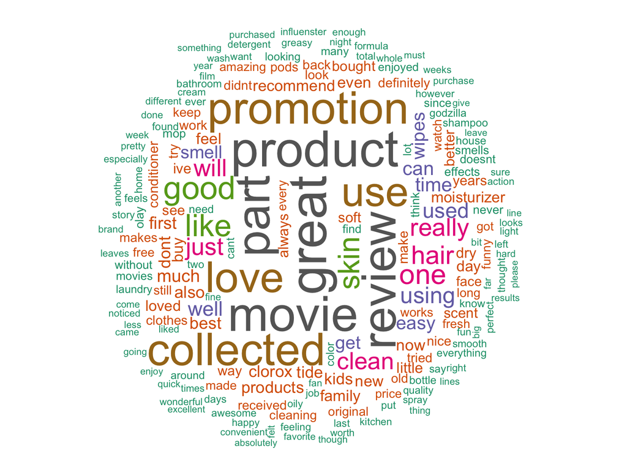

```r
freq_word = colSums(dtm2)
freq_word = sort(freq_word, decreasing = T)
words = names(freq_word)

#plot
wordcloud(words[1:200], freq_word[1:200], random.order = F, colors = brewer.pal(8,'Dark2'))
```

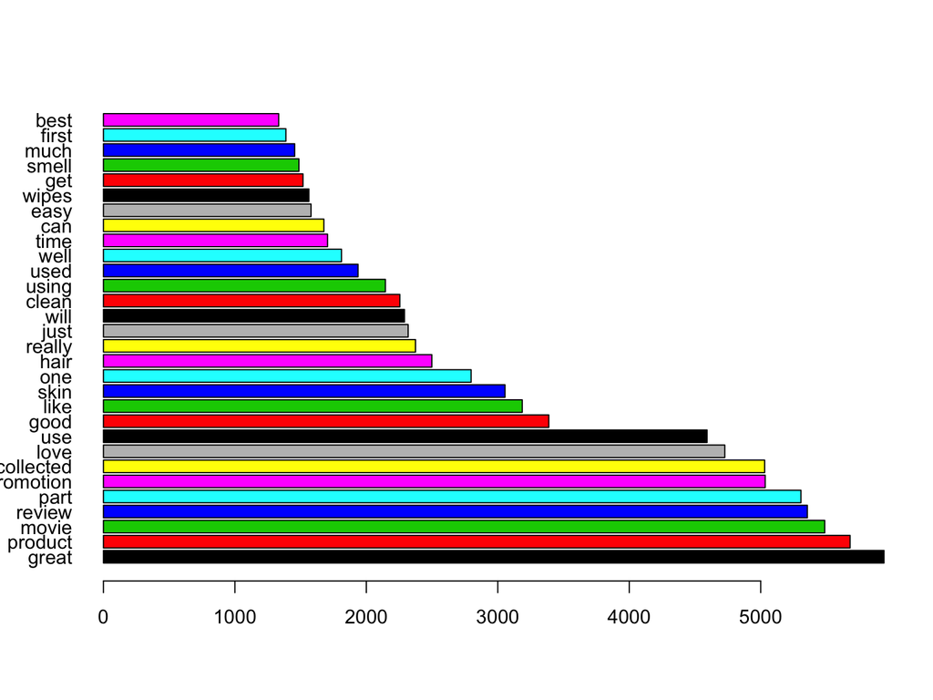

```r
#histogram
freq_matrix = as.matrix(freq_word)
colnames(freq_matrix) = 'n'
cuantos = freq_matrix
freq_matrix = c(row.names(freq_matrix),cuantos)

barplot(head(freq_word,30), horiz = T, las = 1, col = c(1:30))
```

Podemos observar que las palabras que mas se repiten son positivas, esto refleja una reaccion/relacion positiva con los productos. Eso quiere decir que son pocas las personas insatisfechas que realizan un review en el producto.

# Analisis de Sentimientos

De primero hagamos un conteo de palabras.

```r
reviews2 = reviews %>%
  mutate(rowID = row_number())

reviews2$reviews.text = as.character(reviews$reviews.text)
sentimientos = reviews2 %>%
  unnest_tokens(word,reviews.text) %>%
  anti_join(stop_words)
sentimientos %>%
  count(word,sort = T) %>%
  head(.,10)
```

| word | n |
| --- | --- |
| product | 5719 |
| movie | 5540 |
| review | 5363 |
| promotion | 5034 |
| collected | 5030 |
| love | 4753 |
| skin | 3078 |
| hair | 2507 |
| clean | 2310 |
| time | 1726 |

## AFINN-BING-NRC

Calcularemos los sentimientos para cada uno de los reviews usando los diccionarios de AFINN, BING, NRC.

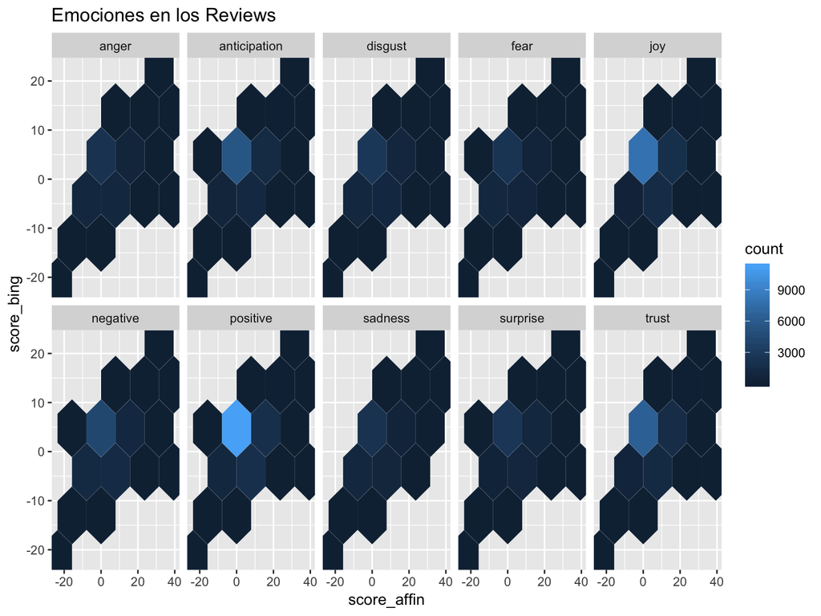

```r
sentimientos_affinn = sentimientos %>%
  inner_join(get_sentiments('afinn'),by = "word") %>%
  group_by(rowID) %>%
  summarise(score_affin = sum(score)) %>%
  ungroup()

sentimientos_bing = sentimientos %>%
  inner_join(get_sentiments("bing"),by="word") %>%
  count(rowID, sentiment) %>%
  spread(sentiment,n,fill = 0) %>%
  mutate(score_bing=positive-negative) %>%
  select(-positive,-negative) %>%
  ungroup()

sentimientos_nrc = sentimientos %>%
  inner_join(get_sentiments("nrc"),by="word") %>%
  count(rowID,sentiment) %>%
  spread(sentiment,n,fill = 0) %>%
  setNames(c(names(.)[1],paste0('nrc_',names(.)[-1]))) %>%
  mutate(score_nrc = nrc_positive - nrc_negative) %>%
  ungroup()

sentimientos_todo = Reduce(full_join, list(sentimientos_affinn,sentimientos_bing,sentimientos_nrc)) %>%
  mutate_each(funs(replace(.,which(is.na(.)),0)))


sentimientos_todo %>%
  gather(emotion,intensity,starts_with("nrc_")) %>%
  filter(intensity > 0) %>%
  mutate(Emotion = substring(emotion,5)) %>%
  ggplot(aes(x=score_affin,y=score_bing)) +
  geom_hex(bins = 4) +
  facet_wrap(~Emotion, nrow = 2) +
  ggtitle("Emociones en los Reviews")
```

Se puede observar que hay mucha tendencia en emociones positivas, de confianza y de alegria, aunque se puede ver que el disgusto y emociones negativas estan presentes.

## Analisis por producto

Ahora veamos que tan positivos o negativos son los reviews de cada producto. Para esto haremos una sumatoria del punteo de BING. Mientras mas alto el puntaje mas positivos son sus opiniones y entre menor sea mas negativo es.

```r
reviews$reviews.text = as.character(reviews$reviews.text)
prueba = reviews

sentimientos = prueba %>%
  unnest_tokens(word,reviews.text) %>%
  anti_join(stop_words)


sentimientos_bing = sentimientos %>%
  inner_join(get_sentiments("bing"),by="word") %>%
  count(name, sentiment) %>%
  spread(sentiment,n,fill = 0) %>%
  mutate(score_bing=positive-negative) %>%
  select(-positive,-negative) %>%
  ungroup()

sentimientos_bing = sentimientos_bing[order(sentimientos_bing$score_bing,decreasing = T),]
```

### Productos mas positivos. Top 10

```r
head(sentimientos_bing,10)
```

| name | score_bing |
| --- | --- |
| Clorox Disinfecting Wipes Value Pack Scented 150 Ct Total | 3283 |
| Olay Total Effects Daily Moisturizer, 7-In-1 Anti-Aging, 0.5oz | 1833 |
| L’or233al Paris Elvive Extraordinary Clay Rebalancing Conditioner - 12.6 Fl Oz | 1805 |
| The Secret Life Of Pets (4k/uhd + Blu-Ray + Digital) | 1442 |
| L’oreal Paris Revitalift Triple Power Deep-Acting Moisturizer | 1104 |
| The Jungle Book (blu-Ray/dvd + Digital) | 802 |
| Clorox Disinfecting Bathroom Cleaner | 794 |
| Quilted Northern Ultra Plush Toilet Paper - 18 Mega Rolls | 651 |
| Tide Pods Detergent, Botanical Rain, 61ct | 603 |
| Independence Day Resurgence (4k/uhd + Blu-Ray + Digital) | 498 |

### Productos mas negativos. Bottom 10

```r
tail(sentimientos_bing,10)
```

| name | score_bing |
| --- | --- |
| Mrs. Meyer’s Lemon Verbena Surface Scrub | -7 |
| Lysol Disinfectant Spray, Early Morning Breeze, 19.0 Ounces | -11 |
| Nexxus Promend Heat Protexx Heat Protection Styling Spray | -12 |
| Pleasant Hearth 1,800 sq ft Wood Burning Stove with Blower, Medium, LWS-127201 | -19 |
| Aveeno Anti-Itch Concentrated Lotion, 4oz | -20 |
| Oxiclean Laundry Stain Remover Spray | -21 |
| Sausage Party (4k/uhd + Digital) | -21 |
| Vicks Vaporub, Regular, 3.53oz | -22 |
| Aveeno Baby Continuous Protection Lotion Sunscreen with Broad Spectrum SPF 55, 4oz | -60 |
| Nexxus Exxtra Gel Style Creation Sculptor | -174 |

## Usuarios y sus reviews

```r
sentimientos_bing = sentimientos %>%
  inner_join(get_sentiments("bing"),by="word") %>%
  count(reviews.username, sentiment) %>%
  spread(sentiment,n,fill = 0) %>%
  mutate(score_bing=positive-negative) %>%
  select(-positive,-negative) %>%
  ungroup()

sentimientos_bing = sentimientos_bing[order(sentimientos_bing$score_bing,decreasing = T),]
```

### Usuarios mas Positivos

```r
head(sentimientos_bing,10)
```

| reviews.username | score_bing |
| --- | --- |
| An anonymous customer | 104 |
| Anonymous | 29 |
|  | 24 |
| Mike | 22 |
| Tranceboi1 | 22 |
| Singlemombeauty | 20 |
| lindsey15 | 19 |
| Stephanie | 17 |
| michellemacd | 17 |
| suenix11 | 16 |

### Usuarios mas Negativos

```r
tail(sentimientos_bing,10)
```

| reviews.username | score_bing |
| --- | --- |
| Raggmopp | -9 |
| Lindylou | -10 |
| MistyK | -10 |
| RachelFre | -10 |
| Rally16 | -10 |
| LaurieB | -11 |
| MadMopper | -11 |
| DirtyDaddy | -13 |
| freckles213 | -15 |
| Martin Asiner | -22 |

## Calidad de los Productores segun Reviews

```r
sentimientos_bing = sentimientos %>%
  inner_join(get_sentiments("bing"),by="word") %>%
  count(manufacturer, sentiment) %>%
  spread(sentiment,n,fill = 0) %>%
  mutate(score_bing=positive-negative) %>%
  select(-positive,-negative) %>%
  ungroup()

sentimientos_bing = sentimientos_bing[order(sentimientos_bing$score_bing,decreasing = T),]
```

### Mejores Productores (mas positivos)

```r
head(sentimientos_bing)
```

| manufacturer | score_bing |
| --- | --- |
| Clorox | 3281 |
| PROCTER & GAMBLE COMPANY, THE | 1833 |
| L’oreal Paris | 1831 |
| Universal | 1533 |
| L’Oreal Paris | 1104 |
| Buena Vista | 802 |

### Peores Productores (mas negativos)

```r
tail(sentimientos_bing)
```

| manufacturer | score_bing |
| --- | --- |
| Reckitt Benckiser | -10 |
| Aveeno | -20 |
| Church & Dwight | -21 |
| Sony Pictures | -21 |
| Aveeno Baby | -60 |
| Nexxus Beauty Products | -174 |

# Estrategia de Negocios

En el analicis anterios, la productora con peores opiniones sobre sus produtos es `Nexxus Beauty Products`. Esta productora solo realiza un solo producto el cual es: Nexxus Exxtra Gel Style Creation Sculptor. Veamos que palabras son las mas usadas para poder dar una recomendacion a `Nexxus Beauty Products` para mejorar sus productos.

```r
prueba = reviews[reviews$manufacturer == 'Nexxus Beauty Products',]

texto = paste(prueba$reviews.text, collapse = " ")
review_source = VectorSource(texto)
corpus = Corpus(review_source)

#limpieza
corpus = tm_map(corpus,content_transformer(tolower))
corpus = tm_map(corpus,content_transformer(removePunctuation))
corpus = tm_map(corpus,content_transformer(removeNumbers))
corpus = tm_map(corpus,stripWhitespace)
corpus = tm_map(corpus,removeWords,tm::stopwords(kind="en"))
```

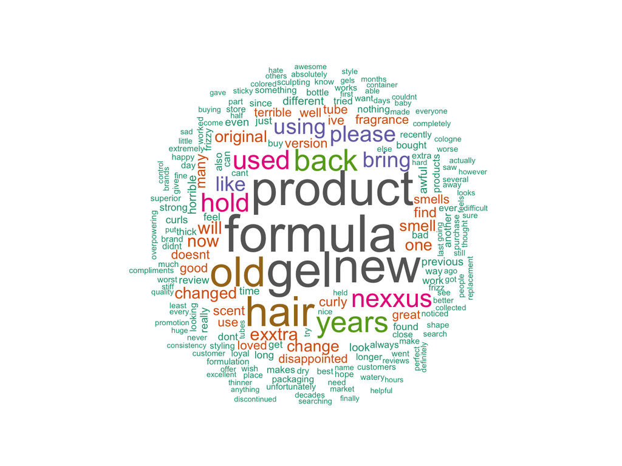

```r
#dtm
dtm = DocumentTermMatrix(corpus)
dtm2 = as.matrix(dtm)

#frecuencia de palabras
freq_word = colSums(dtm2)
freq_word = sort(freq_word, decreasing = T)
words = names(freq_word)

#plot
wordcloud(words[1:200], freq_word[1:200], random.order = F, colors = brewer.pal(8,'Dark2'))
```

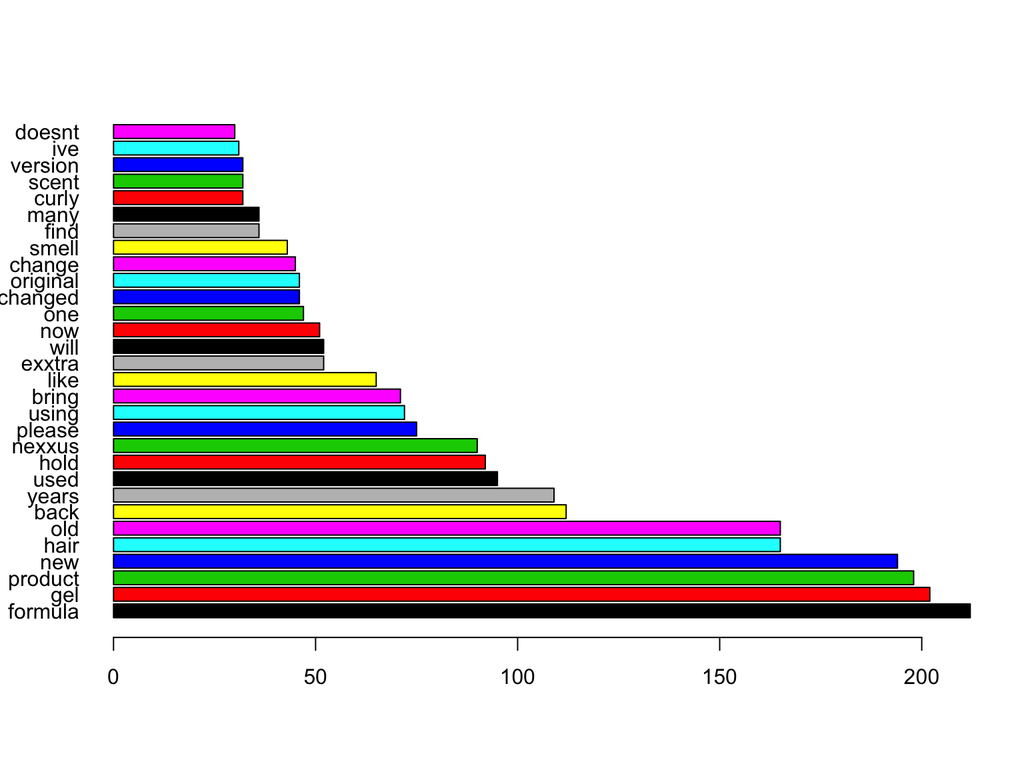

```r
#histogram
freq_matrix = as.matrix(freq_word)
colnames(freq_matrix) = 'n'
cuantos = freq_matrix
freq_matrix = c(row.names(freq_matrix),cuantos)

barplot(head(freq_word,30), horiz = T, las = 1, col = c(1:30))
```